# Machine Learning

# Machine Learning

## Introduction

Arthur Samuel, a pioneer in the field of artificial intelligence who first coined the term ‘Machine Learning’ in 1959, and is known to have developed the Samuel Checkers-playing Program (Samuel, n.d.), widely accepted as the first machine learning program, offered the first of two definitions of machine learning. He described it as “the field of study that gives computers the ability to learn without being explicitly programmed.” For those that do math in Greek, Tom Mitchell offered perhaps a more satisfying definition. “A computer program is said to learn from experience $\epsilon$ with respect to some class of tasks $\tau$ and performance measure, $\rho$, if its performance at tasks $\tau$, as measured by $\rho$, improves with experience $\epsilon$.” (Mitchell 1997).

## Overview of Supervised Learning

## Linear Methods of Regression

## Linear Methods for Classification

## Basis Expansion and Regularization

## Kernel Smoothing Methods

## Model Assessment and Selection

## Model Inference & Averaging

## Additive Models, Trees, and Related Methods

## Boosting and Additive Trees

## Neural Networks

## Support Vector Machines and Flexible Discriminants

## Prototype Methods and Nearest-Neighbors

## Unsupervised Learning

## Random Forests

## Ensemble Learning

## Undirected Graphical Models

## High Dimensional Problems $p >> N$

# Machine Learning with Octave

## Introduction

This section provides a broad introduction to supervised and unsupervised machine learning using Octave, an open-source, scientific programming language (Eaton, John 2017), largely compatible with Matlab (The Mathworks Inc. 2016). Much of the structure, content, and programming problem sets, are drawn from Andrew Ng’s Course on Machine Learning (Ng 2017), delivered on the Coursera platform. For more information on this spectacular course, you are encouraged to visit the Coursera website. A link to the course can be found in the references.

### Learning Objectives

In this section, we will explore, practice, and implement the most effective machine learning techniques used by many practitioners in Silicon Valley, We will learn not only the theoretical foundations, but also the practical aspects that are needed to quickly and powerfully apply these techniques and algorithms to new problems. Topics include: (i) Supervised learning (linear and logistic regression, machine learning algorithms, support vector machines, kernels, and neural networks); (ii) Unsupervised learning (clustering, dimensionality reduction, anomaly detection, recommender systems, and deep learning), and (iii) through case studies, we will explore best practices in the application of machine learning to problems in areas such as robotics, bioinformatics, speech recognition, computer vision, medical diagnosis, stock trading, and others.

### Section Organization

This section is organized as follows:

1. Supervised Learning  
   1.1. Linear Regression  
   1.2. Logistic Regression  
   1.3. Neural Networks  
   1.4. Support Vector Machines
2. Unsupervised Learning  
   2.1. Dimensionality Reduction  
   2.2. Anomaly Detection  
   2.3. Recommender Systems
3. Best Practices  
   3.1. Applying Machine Learning  
   3.2. Machine Learning System Design  
   3.3. Large Scale Machine Learning

The theoretical knowledge and practical skills acquired in this section will enable us to start new careers in machine learning, advance existing careers, and tackle interesting real-world problems in machine learning and artificial intelligence.

## Supervised Learning

There are two types of supervised learning problems: *regression*, and *classification*. In regression, we are attempting to predict a continuous output, by mapping input variables to some continous output or hypothesis function.

Examples of *regression* problems are:

- Predicting the price of a company’s stock or sales in 6 months, given its past performance, the performance of its competitors, and/or macro economic indicators.
- Predicting which potential clients might default on a loan in order to reduce loan qualification rates among high-risk clients, adjust interest rates based on client risk factors, and minimize company losses.
- Modeling the relationship between crime rates and property values and predicting the impact of crime reduction strategies on home prices.
- Designing an SUV that meets Corporate Average Fuel Economy (CAFE) regulations for fuel efficiency, and given the design, predicting the associated highway and city mileage.

*Classification* problems, on the other hand, are about predicting discrete categorical output. Examples include:

- Character and speech recognition applications
- Data Security - Classifying email messages into spam, files as malware, intrusions as threats.
- Personal security - Spot things human screeners might miss in security screenings at airports, stadiums, concerts, and other venues. That can speed up the process significantly and ensure safer events.
- Fraud detection - Tools that compare millions of transactions and can precisely distinguish between legitimate and fraudulent transactions between buyers and sellers.
- Healthcare - Given a patient has a tumor, predict whether the tumor is malignant or benign.

In regression, we are attempting to predict a continuous output, by mapping input variables to some continous output or hypothesis function.

In this section, we’ll exam several techniques for addressing both regression and classification problems. The topics include:  
1.1. Linear Regression  
1.2. Logistic Regression  
1.3. Neural Networks  
1.4. Support Vector Machines

### Linear Regression

Linear regression is a linear approach for modeling the relationship between one or more continuous or discrete independent or explanatory variables and a discrete number or continuous output or dependent variable. It is the most basic type of regression and commonly used in predictive analytics.

#### Data

To motivate the learning process, we’ll take a case study approach, in which we try to develop a machine learning application that can predict housing prices. The data we will use was obtained from the Kaggle House Prices: Advanced Regression Techniques(De Cock 2017). The training set contains 79 features $(x^{(i)})$ and prices $(y^{(i)})$ for 1460 homes in Aimes Iowa. Lets load some data, obtain some summary statistics, and render some plots. For now, we will be interested in lot area (LotArea) in square feet and the sale price (SalePrice).

**Distribution of House Prices**  
The following descriptive statistics describe the house prices in terms of the number of examples $m$, the minimum and maximum house prices, the center in terms of median and mean house price, the standard deviation and standard error. We also have the first and third quartiles as well as the inter-quartile range.

Table 1: Descriptive Statistics for House Prices

[output not shown]

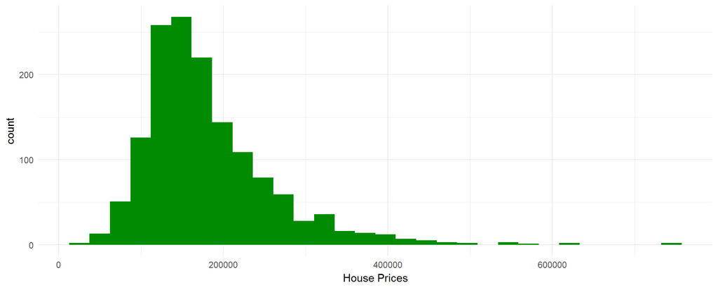

Figure 1: Distribution of House Prices

**Distribution of Lot Areas**  
Similarly, we summarize the distribution of lot areas as follows:

Table 2: Descriptive Statistics for Lot Areas

| m | min | q1 | median | mean | iqr | q3 | max | sd | se |
| --- | --- | --- | --- | --- | --- | --- | --- | --- | --- |
| 1460 | 1300 | 7553.5 | 9478.5 | 10516.83 | 4048 | 11601.5 | 215245 | 9981.265 | 261.2216 |

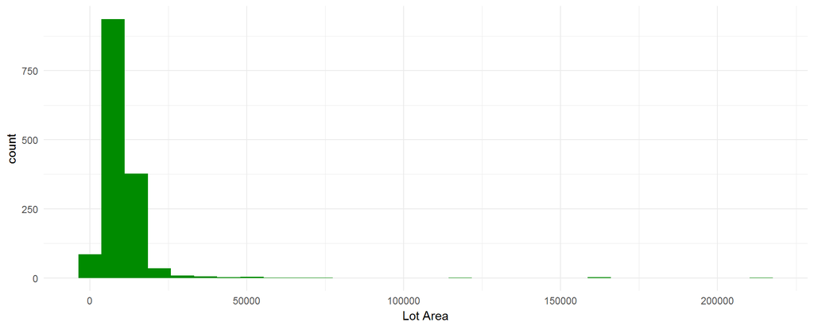

Figure 2: Distribution of Lot Areas

Having familiarized ourselves with the data, let’s develop our intuition on the supervised learning problem, linear regression, and prediction.

#### Supervised Learning Model Representation.

Before we launch, lets align on a few notation points:

**Few notation points**  
1. We denote the $jth$ feature of the $ith$ training example as $x_j^{(i)}$.  
2. We denote the vector of input features for the $ith$ example as $x^{(i)}$.  
3. We denote the outcome variable for the $ith$ training example as $y^{(i)}$,  
4. A pair $(x^{(i)}, y^{(i)})$ is called a training example, and  
5. A list of $m$ training examples $(x^{(i)}, y^{(i)})$; $i = 1,...,m$, is called a *training set*.  
6. Note that the superscript $(i)$ in the notation is an index into the training set, and not an exponentiation.  
7. We will use $X$ to denote the space of input values, and $Y$ to denote the space of output values.  
8. We will denote our prediction as $\hat{Y}$.

That said, we can slightly more formally define the supervised learning problem. Given a training set, our objective is to learn a function $h$: X$\rightarrow$Y, such that $h_\theta(x)$ is a good predictor for the corresponding value of $y$. The process of learning the hypothesis function is also referred to as fitting a linear model to the training set. This model representation is graphically depicted as follows:

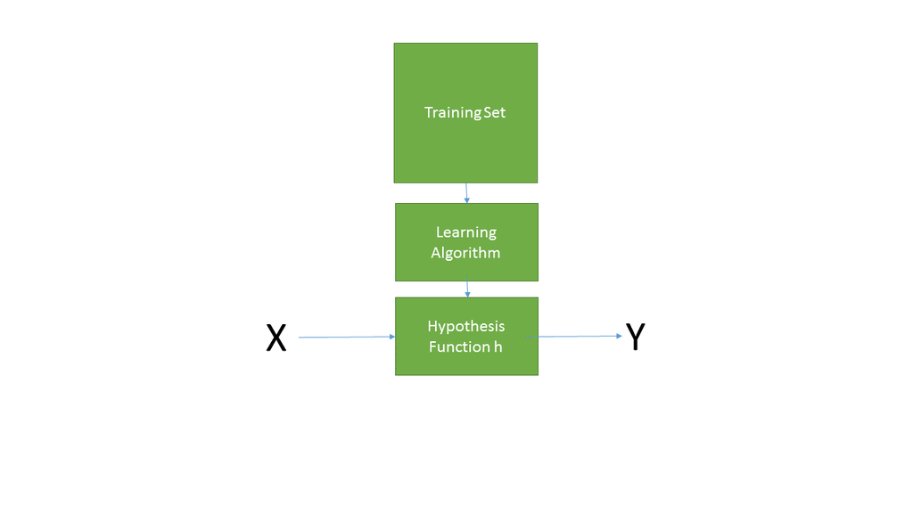

Figure 3: Supervised Learning Model Representation

To illustrate the process of fitting a linear model, lets examine some samples from our training data and let R regress $Y$, the sales price, on $X$, the lot area.

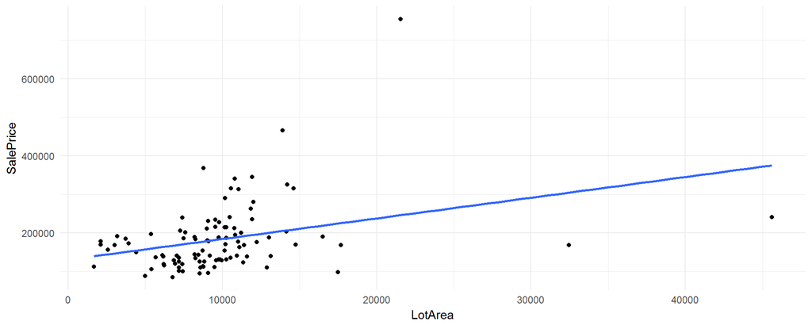

Figure 4: Sales Price by Lot Area

Table 3: Descriptive Statistics for Sample Sales Prices

| m | min | q1 | median | mean | iqr | q3 | max | sd | se |
| --- | --- | --- | --- | --- | --- | --- | --- | --- | --- |
| 100 | 84500 | 128375 | 168000 | 182687.3 | 77875 | 206250 | 755000 | 89628.57 | 8962.857 |

As indicated in Figure 4 and Table 3above, we have 100 housing prices ranging from $84,500 to $755,000, with median price at $168,000 and mean $182,687.3. R has fit a regression line, or *hypothesis function* $h_\theta(x)$, using the *lm* function, giving the form:
$$h_\theta(x^{(i)}) = x_0^{(i)}\theta_0 + x_1^{(i)}\theta_1 = {y^{(i)}}$$
where:
$x_0^{(i)}$ is the intercept or *bias* term $x_1^{(i)}$ is the *first* term,
$\theta_0$ is the coefficient for the *bias* term which we set to 1, and
$\theta_1$ is the coefficient for the *first* term.

The supervised learning task in this example, is to therefore determine the optimal value of $\theta_01$ (since $\theta_0$ is conventionally set to 1) that produce a regression line that best fits the data. In essence, we develop a hypothesis of the value of $\theta_1$, we develop a cost function to evaluate our hypotheses. The best value of $\theta_1$ is that in which the cost, as per our cost function is minimized. Next we more formally define the **hypothesis function**, the **cost function**, and **gradient descent**, an algorithm for determining optimal $\theta$ that minimizes cost of function.

#### The Hypothesis Function

Given a vector of inputs $X^T$ = $X_1, X_2, ..., X_p$, our hypothesis function takes the form:
$$h_\theta(x) = \hat{\theta}_0 + \displaystyle\sum_{i=1}^{p}X_i\hat\theta_i = \hat{Y}$$
. The term $\hat{\theta_0}$ is the intercept, or *bias* term. We essentially sum the product of the vector of inputs $X_i$ and a vector of coefficients or weights, $\theta_i$, for the $ith$ to predict our outcome vector $\hat{Y}$. To vectorize the equation, we typically set $X_0$ to 1 (*the coefficient for the bias term*) and compute the *inner product*:
$$h_\theta(x) = X^T\hat{\theta} = \hat{Y}$$
Alternatively, we use matrix multiplication (*outer product*) and our hypothesis function becomes:
$$h_\theta(x) = \theta^TX = \hat{Y}$$

Therefore, the task is to determine the optimal values for vector $\hat{\theta}$, to produce a linear model that yields the best prediction. We can think of a prediction in terms of minimizing cost, the difference between our predicted value, $\hat{Y}$ and $Y$.

#### The Cost Function

Linear regression has many techniques for fitting a linear model to training data; however, the most popular technique is the *least squares* method. With this approach, we pick the coefficients $\hat{\theta}$ that minimize the *residual sum of squares*.

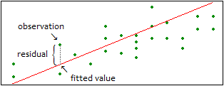

Figure 5: Residuals

As shown in Figure 5, the *residual* is another term for the vertical distance from our regression line to our observed value of $Y$. Since some values of $Y$ will be below our regression line, we square the difference so that all the residuals are positive. The *residual sum of squares* formulation is as follows:
$$RSS(\theta) = \displaystyle\sum_{i=1}^{m}(h_\theta(x^{(i)}) - y^{i})^2$$
The cost function is a generalization of the residual sum of squares formulation. Specifically we take *half of the average* residual sum of squares. This is a mathematical convenience for the computation of hte gradient descent, an algorithm used to minimize the cost function. The derivative term of the square function will cancel out the $1/2$ term. Therefore our linear regression **cost function**, denoted as $J(\theta)$, is as follows:
$$J({\theta}) = 1/2m\displaystyle\sum_{i=1}^{m}h_{\theta}(x^{(i)})- y^{(i)})^2$$

where: $m$ is the number of training examples and $i$ indicates the $ith$ training example.

To find optimal $\theta_0$ and $\theta_1$, our task is to determine $\theta_0$ and $\theta_1$ that minimize cost function $J(\theta)$. Ideally, the best line would fit through all the points of our training data set, such that the value of $J(\theta_0,\theta_1)$ will be 0. The following example illustrates a cost function of 0.

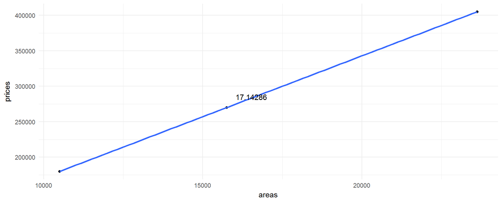

Figure 6: Sales Price by Lot Area

### Logistic Regression

### Neural Networks

### Support Vector Machines

## Unsupervised Learning

2.1. Dimensionality Reduction 2.2. Anomaly Detection 2.3. Recommender Systems

### Dimension Reduction

### Anomaly Detection

### Recommender Systems

# Machine Learning with R

## Introduction

## Creating Features, Preprocessing and Prediction

## Machine Learning Algorithms in R

## Regularized Regression and Combining Predictors

# Machine Learning with Python

## Machine Learning Foundations

## Regression

## Classification

## Clustering and Retrieval

# Machine Learning with R

## Introduction

## Creating Features, Preprocessing and Prediction

## Machine Learning Algorithms in R

## Regularized Regression and Combining Predictors

# References

De Cock, Dean. 2017. “House Prices: Advanced Regression Techniques | Kaggle.” Accessed September 16. https://www.kaggle.com/c/house-prices-advanced-regression-techniques{\#}description https://www.kaggle.com/jimthompson/house-prices-advanced-regression-techniques/ensemble-model-stacked-model-example/notebook.

Eaton, John, W. 2017. “Octave.” doi:10.3169/itej.65.790.

Mitchell, Tom M. (Tom Michael). 1997. *Machine Learning*. McGraw-Hill. http://www.cs.cmu.edu/{~}tom/mlbook.html.

Ng, Andrew. 2017. “Machine Learning | Coursera.” Accessed September 16. https://www.coursera.org/learn/machine-learning/home/info.

Samuel, Arthur L. n.d. “4.3.3 Some Studies in Machine Learning Using the Game of Checkers Some Studies in Machine Learning Using the Game of Checkers.” https://www.cs.virginia.edu/{~}evans/greatworks/samuel1959.pdf.

The Mathworks Inc. 2016. “MATLAB - MathWorks.” doi:2016-11-26.

John James jjames@dataScienceSalon.org

20 September, 2017